# CÁLCULO O RANKING CPC

# PROBLEMA

Calcular a posição dos cursos da UFTM no ranking CPC.

O que é o Conceito Preliminar de Curso? O conceito preliminar de curso (CPC) é calculado no ano seguinte ao da realização do Enade, em cada área, e considera, além do desempenho dos estudantes, o corpo docente, a infraestrutura e os recursos didático-pedagógicos, entre outros itens.

Mais informações  
http://portal.mec.gov.br/component/content/article?id=13074:o-que-e-o-conceito-preliminar-de-curso

# DATASET

https://www.gov.br/inep/pt-br/acesso-a-informacao/dados-abertos/indicadores-educacionais/indicadores-de-qualidade-da-educacao-superior

CARREGAR MÓDULOS

```r
library(dplyr)
library(stringr)

library(ggplot2)
```

CARREGAR O DATASET

```r
dados <- read.csv2("DADOS/Portal_CPC_Edição2019_atualizado.csv")
```

VERIFICAR O TAMANHO DO DATASET

```r
dim(dados)
```

```
[1] 8368   39
```

VERIFICAR OS NOMES DAS COLUNAS DO DATASET

```r
colnames(dados)
```

```
 [1] "Ano"
 [2] "Código.da.Área"
 [3] "Área.de.Avaliação"
 [4] "Código.da.IES"
 [5] "Nome.da.IES"
 [6] "Sigla.da.IES"
 [7] "Organização.Acadêmica"
 [8] "Categoria.Administrativa"
 [9] "Código.do.Curso"
[10] "Modalidade.de.Ensino"
[11] "Código.do.Município"
[12] "Município.do.Curso"
[13] "Sigla.da.UF"
[14] "Nº.de.Concluintes.Inscritos"
[15] "Nº.de.Concluintes.Participantes"
```

[output cut: 24 more lines]

VERIFICAR OS NOMES DA LINHAS DO DATASET

```r
rownames(dados)[1:20]
```

```
 [1] "1"  "2"  "3"  "4"  "5"  "6"  "7"  "8"  "9"  "10" "11" "12" "13" "14" "15" "16" "17" "18" "19" "20"
```

VERIFICAR OS TIPOS DE CADA COLUNA DO DATASET

```r
str(dados)
```

```
'data.frame':   8368 obs. of  39 variables:
 $ Ano                                                     : int  2019 2019 2019 2019 2019 2019 2019 2019 2019 2019 ...
 $ Código.da.Área                                          : int  5 5 5 5 5 5 5 5 5 5 ...
 $ Área.de.Avaliação                                       : chr  "MEDICINA VETERINÁRIA" "MEDICINA VETERINÁRIA" "MEDICINA VETERINÁRIA" "MEDICINA VETERINÁRIA" ...
 $ Código.da.IES                                           : int  1 1 2 3 3 5 5 8 9 10 ...
 $ Nome.da.IES                                             : chr  "UNIVERSIDADE FEDERAL DE MATO GROSSO" "UNIVERSIDADE FEDERAL DE MATO GROSSO" "UNIVERSIDADE DE BRASÍLIA" "UNIVERSIDADE FEDERAL DE SERGIPE" ...
 $ Sigla.da.IES                                            : chr  "UFMT" "UFMT" "UNB" "UFS" ...
 $ Organização.Acadêmica                                   : chr  "Universidade" "Universidade" "Universidade" "Universidade" ...
 $ Categoria.Administrativa                                : chr  "Pública Federal" "Pública Federal" "Pública Federal" "Pública Federal" ...
 $ Código.do.Curso                                         : int  37 100763 18031 1108067 1321453 504 102675 695 777 60123 ...
 $ Modalidade.de.Ensino                                    : chr  "Educação Presencial" "Educação Presencial" "Educação Presencial" "Educação Presencial" ...
 $ Código.do.Município                                     : int  5103403 5107909 5300108 2806701 2804508 2211001 2201903 3171303 4113700 4127700 ...
 $ Município.do.Curso                                      : chr  "Cuiabá" "Sinop" "Brasília" "São Cristóvão" ...
 $ Sigla.da.UF                                             : chr  "MT" "MT" "DF" "SE" ...
 $ Nº.de.Concluintes.Inscritos                             : int  23 46 129 47 28 64 68 62 80 34 ...
```

[output cut: 25 more lines]

VERIFICAR OS TIPOS DE CADA COLUNA DO DATASET

```r
glimpse(dados)
```

```
Rows: 8,368
Columns: 39
$ Ano                                                      <int> 2019, 2019, 2019, 2019, 2019, 2019, 2019, 201~
$ Código.da.Área                                           <int> 5, 5, 5, 5, 5, 5, 5, 5, 5, 5, 5, 5, 5, 5, 5, ~
$ Área.de.Avaliação                                        <chr> "MEDICINA VETERINÁRIA", "MEDICINA VETERINÁRIA~
$ Código.da.IES                                            <int> 1, 1, 2, 3, 3, 5, 5, 8, 9, 10, 10, 13, 17, 20~
$ Nome.da.IES                                              <chr> "UNIVERSIDADE FEDERAL DE MATO GROSSO", "UNIVE~
$ Sigla.da.IES                                             <chr> "UFMT", "UFMT", "UNB", "UFS", "UFS", "UFPI", ~
$ Organização.Acadêmica                                    <chr> "Universidade", "Universidade", "Universidade~
$ Categoria.Administrativa                                 <chr> "Pública Federal", "Pública Federal", "Públic~
$ Código.do.Curso                                          <int> 37, 100763, 18031, 1108067, 1321453, 504, 102~
$ Modalidade.de.Ensino                                     <chr> "Educação Presencial", "Educação Presencial",~
$ Código.do.Município                                      <int> 5103403, 5107909, 5300108, 2806701, 2804508, ~
$ Município.do.Curso                                       <chr> "Cuiabá", "Sinop", "Brasília", "São Cristóvão~
$ Sigla.da.UF                                              <chr> "MT", "MT", "DF", "SE", "SE", "PI", "PI", "MG~
```

[output cut: 26 more lines]

VERIFICAR A QUANTIDADE DE VALORES MISSING

```r
sapply(dados, function(x) sum(is.na(x)))
```

```
                                                     Ano
                                                       0
                                          Código.da.Área
                                                       0
                                       Área.de.Avaliação
                                                       0
                                           Código.da.IES
                                                       0
                                             Nome.da.IES
                                                       0
                                            Sigla.da.IES
                                                       0
                                   Organização.Acadêmica
                                                       0
                                Categoria.Administrativa
                                                       0
                                         Código.do.Curso
                                                       0
                                    Modalidade.de.Ensino
                                                       0
                                     Código.do.Município
                                                       0
                                      Município.do.Curso
                                                       0
                                             Sigla.da.UF
                                                       0
                             Nº.de.Concluintes.Inscritos
                                                       0
                         Nº.de.Concluintes.Participantes
                                                       0
                                         Nota.Bruta...FG
                                                     180
                                   Nota.Padronizada...FG
                                                     180
                                         Nota.Bruta...CE
                                                     180
                                   Nota.Padronizada...CE
                                                     180
                               Conceito.Enade..Contínuo.
                                                     180
```

[output cut: 23 more lines]

```
                                                       0
                                   Nota.Bruta...Doutores
                                                       0
                             Nota.Padronizada...Doutores
                                                       0
                         Nota.Bruta...Regime.de.Trabalho
                                                       0
                   Nota.Padronizada...Regime.de.Trabalho
                                                       0
                                          CPC..Contínuo.
                                                       0
                                             CPC..Faixa.
                                                       0
                                              Observação
                                                       0
```

VERIFICAR A QUANTIDADE DE VALORES NULOS

```r
sapply(dados, function(x) sum(is.null(x)))
```

```
                                                     Ano
                                                       0
                                          Código.da.Área
                                                       0
                                       Área.de.Avaliação
                                                       0
                                           Código.da.IES
                                                       0
                                             Nome.da.IES
                                                       0
                                            Sigla.da.IES
                                                       0
                                   Organização.Acadêmica
                                                       0
                                Categoria.Administrativa
                                                       0
                                         Código.do.Curso
                                                       0
                                    Modalidade.de.Ensino
                                                       0
                                     Código.do.Município
                                                       0
                                      Município.do.Curso
                                                       0
                                             Sigla.da.UF
                                                       0
                             Nº.de.Concluintes.Inscritos
                                                       0
                         Nº.de.Concluintes.Participantes
                                                       0
                                         Nota.Bruta...FG
                                                       0
                                   Nota.Padronizada...FG
                                                       0
                                         Nota.Bruta...CE
                                                       0
                                   Nota.Padronizada...CE
                                                       0
                               Conceito.Enade..Contínuo.
                                                       0
```

[output cut: 23 more lines]

```
                                                       0
                                   Nota.Bruta...Doutores
                                                       0
                             Nota.Padronizada...Doutores
                                                       0
                         Nota.Bruta...Regime.de.Trabalho
                                                       0
                   Nota.Padronizada...Regime.de.Trabalho
                                                       0
                                          CPC..Contínuo.
                                                       0
                                             CPC..Faixa.
                                                       0
                                              Observação
                                                       0
```

VERIFICAR OS TIPOS DA VARIÁVEL CPC_FAIXA

```r
unique(dados$CPC..Faixa.)
```

```
[1] "3"  "4"  "5"  "2"  "1"  "SC" ""
```

VERIFICAR OS VALORES NÃO NUMÉRICOS DA VARIÁVEL CPC_FAIXA

```r
idverificar <- which(dados$CPC..Faixa. %in% c('SC', ''))

ddt <-dados[idverificar, c("Organização.Acadêmica", "Categoria.Administrativa" , "Sigla.da.IES", "CPC..Contínuo.")]

ddt
```

|  | Organização.Acadêmica | Categoria.Administrativa | Sigla.da.IES | CPC..Contínuo. |
| --- | --- | --- | --- | --- |
| 287 | Universidade | Privada sem fins lucrativos | UFN | SC |
| 747 | Universidade | Privada com fins lucrativos |  | SC |
| 830 | Universidade | Pública Estadual | UESPI | SC |
| 1116 | Universidade | Privada com fins lucrativos | UNIAN - SP | SC |
| 1188 | Faculdade | Privada com fins lucrativos |  | SC |
| 1554 | Centro Universitário | Privada com fins lucrativos | UNIRITTER | SC |
| 1724 | Faculdade | Privada com fins lucrativos | FPAS | SC |
| 1914 | Faculdade | Privada com fins lucrativos |  | SC |
| 2026 | Universidade | Privada com fins lucrativos | UNIAN - SP | SC |
| 2057 | Faculdade | Privada sem fins lucrativos | FACCI | SC |

[output cut: 170 more lines]

GRUPAR E CONTAR OS VALORES NÃO NUMÉRICOS DA VARIÁVEL CPC_FAIXA

```r
ddt %>%
  group_by(`Categoria.Administrativa`, `Organização.Acadêmica`) %>%
  summarise(n = n(), .groups = 'drop')
```

| Categoria.Administrativa | Organização.Acadêmica | n |
| --- | --- | --- |
| Privada com fins lucrativos | Centro Universitário | 22 |
| Privada com fins lucrativos | Faculdade | 71 |
| Privada com fins lucrativos | Universidade | 38 |
| Privada sem fins lucrativos | Centro Universitário | 19 |
| Privada sem fins lucrativos | Faculdade | 6 |
| Privada sem fins lucrativos | Universidade | 13 |
| Pública Estadual | Universidade | 5 |
| Pública Federal | Universidade | 5 |
| Pública Municipal | Universidade | 1 |

```r
ddt <- dados[idverificar,] %>%
  filter(Código.da.IES == 579) %>%
  select(Nome.da.IES)

unique(ddt)
```

| Nome.da.IES |
| --- |

VERIFICAR AS INSTITUIÇÕES QUE NÃO POSSUI VALORES NUMÉRICOS DA VARIÁVEL CPC_FAIXA

```r
ddt <- dados[idverificar,] %>%
  filter(Código.da.IES != 579) %>%
  select(Nome.da.IES)

unique(ddt[order(ddt),])
```

```
  [1] "CENTRO REGIONAL UNIVERSITÁRIO DE ESPÍRITO SANTO DO PINHAL"
  [2] "CENTRO UNIVERSITÁRIO ANHANGUERA DE NITERÓI"
  [3] "CENTRO UNIVERSITÁRIO ANHANGUERA DE SÃO PAULO"
  [4] "CENTRO UNIVERSITÁRIO AUGUSTO MOTTA"
  [5] "Centro Universitário Campo Limpo Paulista"
  [6] "CENTRO UNIVERSITÁRIO CAMPOS DE ANDRADE"
  [7] "CENTRO UNIVERSITÁRIO CATÓLICA DO TOCANTINS"
  [8] "CENTRO UNIVERSITÁRIO DAS FACULDADES METROPOLITANAS UNIDAS"
  [9] "CENTRO UNIVERSITÁRIO DE BELO HORIZONTE"
 [10] "CENTRO UNIVERSITÁRIO DE LINS"
 [11] "CENTRO UNIVERSITÁRIO DO RIO DE JANEIRO"
 [12] "CENTRO UNIVERSITÁRIO ESTÁCIO DA AMAZÔNIA"
 [13] "CENTRO UNIVERSITÁRIO ESTÁCIO DE BRASÍLIA - ESTÁCIO BRASÍLIA"
 [14] "CENTRO UNIVERSITÁRIO ESTÁCIO DE SANTA CATARINA - ESTÁCIO SANTA CATARINA"
 [15] "Centro Universitário Estácio do Ceará"
```

[output cut: 104 more lines]

EXCLUIR OS REGISTROS NÃO NUMÉRICOS

```r
dados <- dados[-idverificar, ]
```

VERIFICAR SE TODOS VALORES SÃO NUMÉRICOS

```r
tb <- c()
for (vl in dados$CPC..Contínuo.){
  if (str_count(vl, ',') == 0){
    tb <- append(x = tb, values = vl)
  }
}

tb
```

```
 [1] "4" "4" "2" "3" "3" "3" "2" "3" "4" "2" "2" "3" "3" "2" "3" "2"
```

TRANSFORMAR OS VALORES DE TEXTO PARA NUMÉRICOS

```r
dados$CPC..Faixa. <- as.double(dados$CPC..Faixa.)
```

TRANSFORMAR OS VALORES DE TEXTO PARA NUMÉRICOS

```r
lista <- dados$CPC..Contínuo.

listanumerica <- as.double(str_replace(lista, ',', '.'))

dados$CPC..Contínuo. <- listanumerica
```

VERIFICAR O HISTROGRAMA DA VARIÁVEL CPC

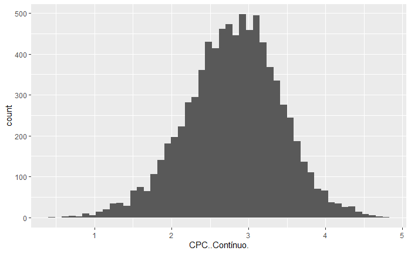

```r
ggplot(dados) +
  aes(CPC..Contínuo.) +
  geom_histogram(bins = 50)
```

VERIFICAR O BOXPLOT DA VARIÁVEL CPC

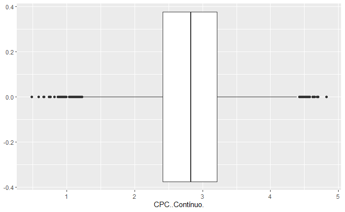

```r
ggplot(dados) +
  aes(x = CPC..Contínuo.) +
  geom_boxplot()
```

VERIFICAR OS CURSOS QUE SERÃO CALCULADOS OS RANKING

```r
cursos <- dados[which(dados$Código.da.IES == 597), "Área.de.Avaliação"]
cursos
```

```
 [1] "MEDICINA"                      "ENFERMAGEM"                    "NUTRIÇÃO"
 [4] "FISIOTERAPIA"                  "BIOMEDICINA"                   "EDUCAÇÃO FÍSICA (BACHARELADO)"
 [7] "ENGENHARIA CIVIL"              "ENGENHARIA ELÉTRICA"           "ENGENHARIA MECÂNICA"
[10] "ENGENHARIA DE ALIMENTOS"       "ENGENHARIA QUÍMICA"            "ENGENHARIA DE PRODUÇÃO"
[13] "ENGENHARIA AMBIENTAL"
```

VERIFICAR O BOXPLOT DA VARIÁVEL CPC - SOMENTE PARA OS CURSOS

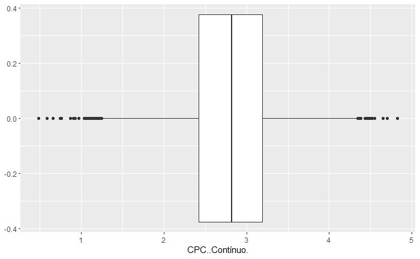

```r
ddt <- dados %>% filter( Área.de.Avaliação %in% cursos)
ggplot(ddt) +
  aes(x = CPC..Contínuo.) +
  geom_boxplot()
```

VERIFICAR O BOXPLOT DA VARIÁVEL CPC - SOMENTE PARA OS CURSOS

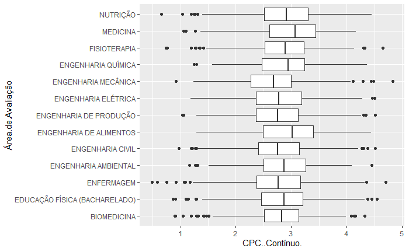

```r
ddt <- dados %>% filter( Área.de.Avaliação %in% cursos)
ggplot(ddt) +
  aes(x = CPC..Contínuo., y = Área.de.Avaliação) +
  geom_boxplot()
```

FUNÇÃO PARA CRIAR O RANKING DO CPC

```r
calculo_ranking_cpc <- function(dados, curso){
  "FUNÇÃO PARA CRIAR O RAMKING DO CPC
  ENTRA
    DATASET E O CURSO
  SAI
    RANKING POR: BR, REGIÃO, UF; NOTA, FAIXA DO CPC"

  # FILTRA OS DADOS DA INSTITUIÇÃO
  ddt <- dados %>%
    filter(`Área.de.Avaliação` == curso & `Código.da.IES` == 597)
  # PEGAR A NOTA E A FAIXA
  nota <- ddt$CPC..Contínuo.
  faixa <- ddt$CPC..Faixa.

  # PEGAR A POSIÇÃO DO RANKING BR
  ddt <- dados %>%
    filter(`Área.de.Avaliação` == curso) %>%
    arrange(desc(CPC..Contínuo.), `Nome.da.IES`)

  ranking_br <- which(ddt$Código.da.IES == 597)

  # PEGAR A POSIÇÃO DO RANKING REGIÃO
  ddt <- dados %>%
  filter(`Área.de.Avaliação` == curso, `Sigla.da.UF` %in% c('MG', 'SP', 'RJ', 'ES')) %>%
  arrange(desc(CPC..Contínuo.), `Nome.da.IES`)

  ranking_regiao <- which(ddt$Código.da.IES == 597)

  # PEGAR A POSIÇÃO DO RANKING UF
  ddt <- dados %>%
  filter(`Área.de.Avaliação` == curso, `Sigla.da.UF` == 'MG') %>%
  arrange(desc(CPC..Contínuo.), `Nome.da.IES`)

  ranking_uf <- which(ddt$Código.da.IES == 597)

  return( c(ranking_br, ranking_regiao, ranking_uf, nota, faixa))
}
```

FAZER LOOP NOS CURSOS E CALCULAR O RANKING

```r
tb <- c()
for (curso in cursos){
  vl <- calculo_ranking_cpc(dados, curso)
  tb <- rbind(tb, vl)
}

resultado <- as.data.frame(tb)
rownames(resultado) <- cursos
colnames(resultado) <- c('ranking_br', 'ranking_regiao', 'ranking_uf',  'CPC_Contínuo', 'CPC_Faixa')

resultado
```

|  | ranking_br | ranking_regiao | ranking_uf | CPC_Contínuo | CPC_Faixa |
| --- | --- | --- | --- | --- | --- |
| MEDICINA | 69 | 31 | 13 | 3.334 | 4 |
| ENFERMAGEM | 26 | 8 | 3 | 3.753 | 4 |
| NUTRIÇÃO | 78 | 39 | 13 | 3.455 | 4 |
| FISIOTERAPIA | 9 | 3 | 2 | 4.040 | 5 |
| BIOMEDICINA | 32 | 14 | 2 | 3.467 | 4 |
| EDUCAÇÃO FÍSICA (BACHARELADO) | 51 | 27 | 7 | 3.540 | 4 |
| ENGENHARIA CIVIL | 76 | 28 | 12 | 3.432 | 4 |
| ENGENHARIA ELÉTRICA | 64 | 37 | 15 | 3.374 | 4 |
| ENGENHARIA MECÂNICA | 54 | 31 | 11 | 3.125 | 4 |
| ENGENHARIA DE ALIMENTOS | 28 | 11 | 5 | 3.294 | 4 |

[output cut: 3 more lines]

SALVAR O RESULTADO DO CÁLCULO

```r
write.csv2(resultado, file = 'RESULTADOS/CALCULO - CPC - RANKING.csv', na = "", quote = FALSE)
```